# Analysis of presidential inaugural speeches - based on Party

# Introduction

### Inaugural speech is not only the the first official speech of any president of United States, but also reflects the personality, sentiment, interested topics for the next few years and so on. The following analysis mainly focus on the difference of inaugural speeches between Democratic Party and Republican Party(part 1). Then, we compare the inaugural speeches of DonaldJTrump and BarackObama(part 2).

```
 [1] "1789-04-30" "1793-03-04" "1797-03-04" "1801-03-04" "1805-03-04" "1809-03-04" "1813-03-04"
 [8] "1817-03-04" "1821-03-04" "1825-03-04" "1829-03-04" "1833-03-04" "1837-03-04" "1841-03-04"
[15] "1845-03-04" "1849-03-05" "1853-03-04" "1857-03-04" "1861-03-04" "1865-03-04" "1869-03-04"
[22] "1873-03-04" "1877-03-05" "1881-03-04" "1885-03-04" "1889-03-04" "1893-03-04" "1897-03-04"
[29] "1901-03-04" "1905-03-04" "1909-03-04" "1913-03-04" "1917-03-04" "1921-03-04" "1925-03-04"
[36] "1929-03-04" "1933-03-04" "1937-01-20" "1941-01-20" "1945-01-20" "1949-01-20" "1953-01-20"
[43] "1957-01-21" "1961-01-20" "1965-01-20" "1969-01-20" "1973-01-20" "1977-01-20" "1981-01-20"
[50] "1985-01-21" "1989-01-20" "1993-01-20" "1997-01-20" "2001-01-20" "2005-01-20" "2009-01-20"
[57] "2013-01-21" "2017-01-20" NA
```

|  | President | File | Term | Party | Date | Words | Win | type | links | urls | fulltext |
| --- | --- | --- | --- | --- | --- | --- | --- | --- | --- | --- | --- |
| 1 | George Washington | GeorgeWashington | 1 | NA | April 30, 1789 | 1422 | Yes | inaug | April 30, 1789 | http://www.presidency.ucsb.edu/ws/index.php?pid=25800 | Fellow-Citizens of the Senate and of the House of Representatives:Among the vicissitudes incident to life no event could have filled me with greater anxieties than that of which the notification was t… |
| 2 | George Washington | GeorgeWashington | 2 | NA | March 4, 1793 | 133 | Yes | inaug | March 4, 1793 | http://www.presidency.ucsb.edu/ws/index.php?pid=25801 | Fellow Citizens:I AM again called upon by the voice of my country to execute the functions of its Chief Magistrate. When the occasion proper for it shall arrive, I shall endeavor to express the high s… |
| 3 | John Adams | JohnAdams | 1 | Fedralist | March 4, 1797 | 2306 | Yes | inaug | March 4, 1797 | http://www.presidency.ucsb.edu/ws/index.php?pid=25802 | WHEN it was first perceived, in early times, that no middle course for America remained between unlimited submission to a foreign legislature and a total independence of its claims, men of reflection … |
| 4 | Thomas Jefferson | ThomasJefferson | 1 | Democratic-Republican Party | March 4, 1801 | 1711 | Yes | inaug | March 4, 1801 | http://www.presidency.ucsb.edu/ws/index.php?pid=25803 | Friends and Fellow-Citizens:CALLED upon to undertake the duties of the first executive office of our country, I avail myself of the presence of that portion of my fellow-citizens which is here assembl… |
| 5 | Thomas Jefferson | ThomasJefferson | 2 | Democratic-Republican Party | March 4, 1805 | 2143 | Yes | inaug | March 4, 1805 | http://www.presidency.ucsb.edu/ws/index.php?pid=25804 | PROCEEDING, fellow-citizens, to that qualification which the Constitution requires before my entrance on the charge again conferred on me, it is my duty to express the deep sense I entertain of this n… |
| 6 | James Madison | JamesMadison | 1 | Democratic-Republican Party | March 4, 1809 | 1167 | Yes | inaug | March 4, 1809 | http://www.presidency.ucsb.edu/ws/index.php?pid=25805 | Unwilling to depart from examples of the most revered authority, I avail myself of the occasion now presented to express the profound impression made on me by the call of my country to the station to … |

### Above is the dataset we constructed, which contains information related to inaugural speech like Party, number of words, date and so on.

# Part 1: The story of inaugural speeches of Democratic Party and Republican Party

### It is well known that Democrats and republicans have different platforms, development goals and different interests. So what are the similarities and differences of their speeches?

## 1.1 The change of number of words over time

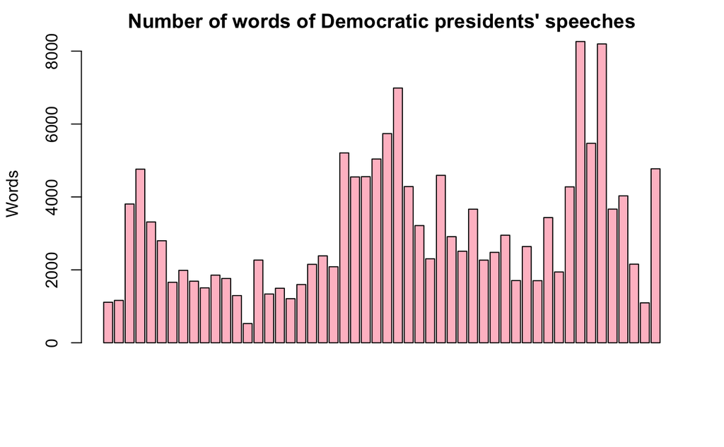

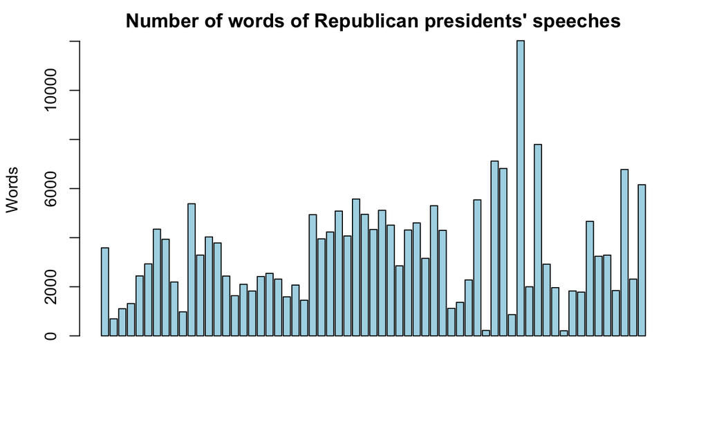

### According to the barplot above, we may see that:

### For Democratic presidents’ speeches:

### (1) Most of the speeches are under 4000 words.

### (2) The number of words fluctuate over time.

### (3) As time goes by, there is a slight trend that their speeches contain more and more words.

### For Republican presidents’ speeches:

### (1) Most of the speeches are under 5000 words.

### (2) The number of words fluctuate over time.

### (3) As time goes by, there is a slight trend that their speeches contain more and more words.

### It seems like that the word average number of Republican presidents’ speeches is more than that of Democratic presidents’ speeches. Is it right?

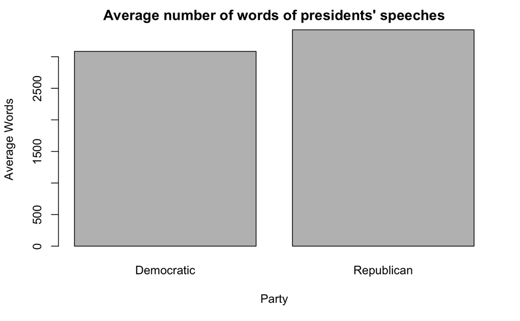

### According to the graph above, we can see that the average word number of Democratic presidents’ speeches is about 3000. As for Republican presidents’ speeches, it is about 3500. So we have the right guess.